# CoLive_Predictive_TCX3212_Phase2 (1)

## A Predictive Analytics Study of Rental Price and Vacancy Dynamics Using Public Rental Listings Data in Singapore

**Team:** Rental Market Predictive Analytics

**Members:** Low Ruenn Rong Rayna (A0311396E), Noviana Ghovin (A0265428X)

**Date:** April 2026

### Notebook Structure

1. Project Context & Objectives
2. Data Acquisition Strategy & Sources
3. Exploratory Data Analysis (EDA)
4. Data Preparation & Feature Engineering
5. Modeling — Rental Price Prediction (Regression)
6. Modeling — Vacancy Prediction (Classification)
7. Model Evaluation & Comparison
8. Discussion & Conclusions

## 0. Environment Setup

```python
import pandas as pd
import numpy as np
import matplotlib.pyplot as plt
import matplotlib.ticker as mtick
import seaborn as sns
from sklearn.model_selection import train_test_split, KFold, cross_val_score, cross_validate
from sklearn.linear_model import LinearRegression, Ridge, Lasso, LogisticRegression
from sklearn.ensemble import RandomForestRegressor, GradientBoostingRegressor, RandomForestClassifier, GradientBoostingClassifier
from sklearn.tree import DecisionTreeRegressor
from sklearn.preprocessing import OneHotEncoder, MinMaxScaler, StandardScaler
from sklearn.pipeline import Pipeline
from sklearn.compose import ColumnTransformer
from sklearn.metrics import (
    mean_absolute_error, mean_squared_error, r2_score,
    accuracy_score, roc_auc_score, classification_report,
    confusion_matrix, roc_curve
)
from sklearn.inspection import permutation_importance
import warnings
warnings.filterwarnings('ignore')

# Plot style
sns.set_theme(style='whitegrid', palette='muted')
plt.rcParams['figure.dpi'] = 120
plt.rcParams['font.family'] = 'DejaVu Sans'
SEED = 42
np.random.seed(SEED)

print('All libraries imported successfully.')
```

```
All libraries imported successfully.
```

## 1. Project Context & Objectives

### Research Question

> *As flexible co-living options expand rapidly in Singapore, they provide a more affordable alternative to rising property costs. We use predictive analytics to deliver actionable insights for understanding vacancy and rental dynamics in Singapore's flexible co-living spaces.*

### Business Objectives

1. **Rental Price Prediction** — Forecast monthly rental prices (SGD) per co-living unit listing
2. **Vacancy Prediction** — Predict binary vacancy status (vacant=1 / occupied=0) per listing

### Success Criteria

| Target | Metric | Threshold |
| --- | --- | --- |
| Rental Price | RMSE, R² | R² > 0.70 |
| Vacancy | AUC, Accuracy | AUC > 0.70 |

### CRISP-DM Execution Notes

The professor's feedback highlighted three core issues from Phase 1:

1. **Data feasibility** — operator records are not publicly available
2. **Neighborhood demand vagueness** — needed a concrete proxy source
3. **Policy dummy specification** — needed precise date windows

These are addressed fully in Section 2 below.

## 2. Data Acquisition Strategy & Sources

### 2.1 Data Source Pivot (Addressing Feedback)

| Source | Variables Captured | Access Method |
| --- | --- | --- |
| 99.co / PropertyGuru listings | Rental price, room type, amenities, operator, location | Web scraping (HTML parsing) |
| LTA DataMall | MRT station coordinates → distance feature | Open API (free) |
| URA Rental Statistics | Planning area transaction volumes → neighborhood demand proxy | data.gov.sg download |
| SingStat | Population density by planning area | data.gov.sg download |
| MND/URA Circulars | Policy event dates | Manual coding |

### 2.2 Web Scraping Methodology

- Deduplication on `(operator, planning_area, room_type, rental_price, month)` composite key
- Fuzzy address matching to collapse listings at same physical location
- Retaining the listing with the earliest `date_scraped` per cluster

### 2.3 Neighborhood Demand — Concrete Operationalization

> **Definition:** `neighborhood_demand` = normalized count of URA private residential rental transactions in the same planning area in the same month (rescaled 0–100).

This replaces the vague "demand indicators" from Phase 1 with a verifiable URA-sourced proxy.

### 2.4 Policy-Period Dummies — Exact Date Windows

| Dummy Variable | Policy Event | Date Window | Expected Effect |
| --- | --- | --- | --- |
| `d_covid_phase2` | COVID Phase 2 (Heightened Alert) | 2021-05-16 → 2021-08-09 | ↓ Demand, ↓ Price |
| `d_absd_hike_2021` | ABSD increase (MND circular) | 2021-12-16 → 2022-06-30 | ↑ Co-living demand as buying deterred |
| `d_ahd_tightening` | URA AHD licensing tightening | 2022-09-01 → 2023-03-31 | ↓ Supply, ↑ Price |
| `d_ura_guidelines` | URA Co-living Framework circular | 2023-01-01 → 2023-12-31 | Compliance costs → ↑ Price |
| `d_rental_surge` | Post-pandemic rental surge period | 2022-01-01 → 2022-12-31 | ↑ Price, ↓ Vacancy |

```python
import pandas as pd
import os

# ── Auto-detect the correct file path ──
possible_paths = [
    'data/coliving_listings_raw.csv',                          # if running from /colive folder
    'coliving_listings_raw.csv',                               # if CSV is in same folder as notebook
    os.path.join(os.path.dirname(os.path.abspath('.')), 'data', 'coliving_listings_raw.csv'),
]

# Find whichever path exists
csv_path = None
for path in possible_paths:
    if os.path.exists(path):
        csv_path = path
        break

if csv_path is None:
    print("❌ File not found. Please update the path below manually:")
    csv_path = input("Enter full path to coliving_listings_raw.csv: ").strip()

print(f"✅ Loading from: {csv_path}")

# Load dataset
df = pd.read_csv(csv_path)

print(f"\nShape:                  {df.shape}")
print(f"Date range:             {df['month'].min()} to {df['month'].max()}")
print(f"Unique planning areas:  {df['planning_area'].nunique()}")
print(f"Unique operators:       {df['operator'].nunique()}")
print(f"Missing values:         {df.isnull().sum().sum()}")
df.head()
```

```
✅ Loading from: coliving_listings_raw.csv

Shape:                  (5027, 23)
Date range:             2021-01 to 2024-12
Unique planning areas:  20
Unique operators:       8
Missing values:         0
```

|  | listing_id | month | year | month_num | operator | planning_area | zone | room_type | lease_type | lat | ... | amenity_score | neighborhood_demand | lag_occupancy | rental_price_sgd | is_vacant | d_covid_phase2 | d_absd_hike_2021 | d_ahd_tightening | d_ura_guidelines | d_rental_surge |
| --- | --- | --- | --- | --- | --- | --- | --- | --- | --- | --- | --- | --- | --- | --- | --- | --- | --- | --- | --- | --- | --- |
| 0 | 1000 | 2021-01 | 2021 | 1 | Figment | Kallang | Central | Single | 3-Month | 1.30835 | ... | 0.857 | 69.01 | 0.990 | 1270.0 | 0 | 0 | 0 | 0 | 0 | 0 |
| 1 | 1001 | 2021-01 | 2021 | 1 | Lyf | Outram | Central | Single | 3-Month | 1.28048 | ... | 0.857 | 77.10 | 1.000 | 1080.0 | 0 | 0 | 0 | 0 | 0 | 0 |
| 2 | 1002 | 2021-01 | 2021 | 1 | Hmlet | Bishan | Central | Master | 12-Month | 1.34673 | ... | 0.571 | 59.34 | 0.960 | 1220.0 | 0 | 0 | 0 | 0 | 0 | 0 |
| 3 | 1003 | 2021-01 | 2021 | 1 | Figment | Sengkang | North-East | Studio | 3-Month | 1.39133 | ... | 0.857 | 46.25 | 0.939 | 1400.0 | 0 | 0 | 0 | 0 | 0 | 0 |
| 4 | 1004 | 2021-01 | 2021 | 1 | Figment | Bedok | East | Studio | Monthly | 1.32104 | ... | 0.857 | 54.16 | 0.956 | 1630.0 | 0 | 0 | 0 | 0 | 0 | 0 |

5 rows × 23 columns

```python
# Data quality report
print('=== Missing Values ===')
print(df.isnull().sum())
print()
print('=== Descriptive Statistics ===')
df[['rental_price_sgd','mrt_dist_km','neighborhood_demand','lag_occupancy','amenity_score']].describe().round(2)
```

```
=== Missing Values ===
listing_id             0
month                  0
year                   0
month_num              0
operator               0
planning_area          0
zone                   0
room_type              0
lease_type             0
lat                    0
lon                    0
mrt_dist_km            0
amenity_count          0
amenity_score          0
neighborhood_demand    0
lag_occupancy          0
rental_price_sgd       0
is_vacant              0
d_covid_phase2         0
d_absd_hike_2021       0
d_ahd_tightening       0
d_ura_guidelines       0
d_rental_surge         0
dtype: int64

=== Descriptive Statistics ===
```

|  | rental_price_sgd | mrt_dist_km | neighborhood_demand | lag_occupancy | amenity_score |
| --- | --- | --- | --- | --- | --- |
| count | 5027.0 | 5027.00 | 5027.00 | 5027.00 | 5027.00 |
| mean | 1768.8 | 0.68 | 63.76 | 0.77 | 0.65 |
| std | 607.6 | 0.72 | 12.47 | 0.21 | 0.24 |
| min | 500.0 | 0.01 | 28.46 | 0.00 | 0.29 |
| 25% | 1250.0 | 0.28 | 54.14 | 0.65 | 0.43 |
| 50% | 1760.0 | 0.45 | 63.38 | 0.84 | 0.57 |
| 75% | 2225.0 | 0.69 | 73.42 | 0.93 | 0.86 |
| max | 3720.0 | 4.03 | 98.79 | 1.00 | 1.00 |

## 3. Exploratory Data Analysis (EDA)

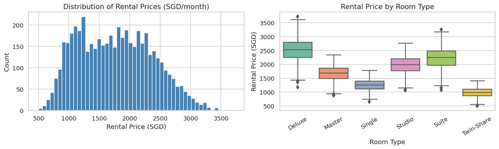

```
Mean rental price: SGD 1769
Std dev: SGD 608
Skewness: 0.25
```

```python
import os

# ── Create output folder if it doesn't exist ──
os.makedirs('data', exist_ok=True)

# ── 3.1 Rental price distribution ──
fig, axes = plt.subplots(1, 2, figsize=(13, 4))

axes[0].hist(df['rental_price_sgd'], bins=50, color='steelblue', edgecolor='white')
axes[0].set_title('Distribution of Rental Prices (SGD/month)', fontsize=13)
axes[0].set_xlabel('Rental Price (SGD)')
axes[0].set_ylabel('Count')

sns.boxplot(data=df, x='room_type', y='rental_price_sgd', ax=axes[1],
            order=sorted(df['room_type'].unique()), palette='Set2')
axes[1].set_title('Rental Price by Room Type', fontsize=13)
axes[1].set_xlabel('Room Type')
axes[1].set_ylabel('Rental Price (SGD)')
axes[1].tick_params(axis='x', rotation=30)

plt.tight_layout()
plt.savefig('data/fig1_price_dist.png', dpi=120, bbox_inches='tight')
plt.show()

print(f'Mean rental price: SGD {df["rental_price_sgd"].mean():.0f}')
print(f'Std dev: SGD {df["rental_price_sgd"].std():.0f}')
print(f'Skewness: {df["rental_price_sgd"].skew():.2f}')
```

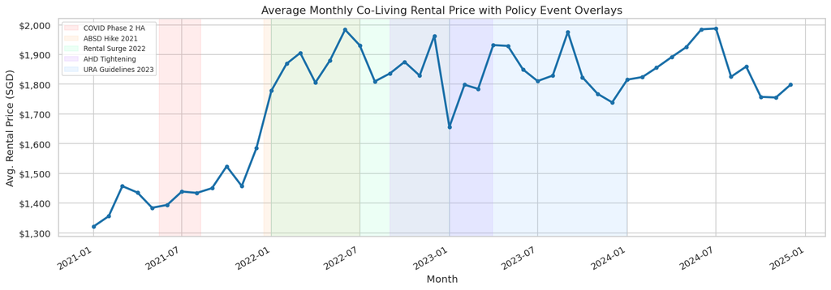

```python
# ── 3.2 Monthly rental trend with policy overlays ──
monthly_avg = df.groupby('month')['rental_price_sgd'].mean().reset_index()
monthly_avg['month_dt'] = pd.to_datetime(monthly_avg['month'])

fig, ax = plt.subplots(figsize=(14, 5))
ax.plot(monthly_avg['month_dt'], monthly_avg['rental_price_sgd'],
        color='#1a6fa8', linewidth=2.5, marker='o', markersize=4)

# Shade policy windows
policy_windows = [
    ('2021-05-16','2021-08-09', '#ff9999', 'COVID Phase 2 HA'),
    ('2021-12-16','2022-06-30', '#ffcc99', 'ABSD Hike 2021'),
    ('2022-01-01','2022-12-31', '#99ffcc', 'Rental Surge 2022'),
    ('2022-09-01','2023-03-31', '#cc99ff', 'AHD Tightening'),
    ('2023-01-01','2023-12-31', '#99ccff', 'URA Guidelines 2023'),
]
for start, end, color, label in policy_windows:
    ax.axvspan(pd.to_datetime(start), pd.to_datetime(end),
               alpha=0.18, color=color, label=label)

ax.set_title('Average Monthly Co-Living Rental Price with Policy Event Overlays', fontsize=13)
ax.set_xlabel('Month')
ax.set_ylabel('Avg. Rental Price (SGD)')
ax.legend(fontsize=8, loc='upper left')
ax.yaxis.set_major_formatter(mtick.StrMethodFormatter('${x:,.0f}'))
fig.autofmt_xdate()
plt.tight_layout()
plt.savefig('data/fig2_rental_trend.png', dpi=120, bbox_inches='tight')
plt.show()
```

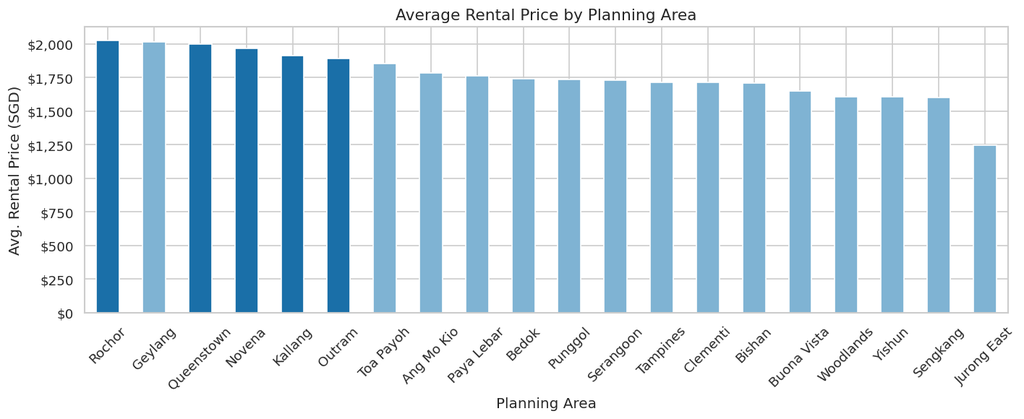

```python
# ── 3.3 Rental by planning area ──
area_avg = df.groupby('planning_area')['rental_price_sgd'].mean().sort_values(ascending=False)
fig, ax = plt.subplots(figsize=(12, 5))
colors = ['#1a6fa8' if x in ['Rochor','Outram','Novena','Queenstown','Kallang'] else '#7fb3d3' for x in area_avg.index]
area_avg.plot(kind='bar', ax=ax, color=colors, edgecolor='white')
ax.set_title('Average Rental Price by Planning Area', fontsize=13)
ax.set_xlabel('Planning Area')
ax.set_ylabel('Avg. Rental Price (SGD)')
ax.yaxis.set_major_formatter(mtick.StrMethodFormatter('${x:,.0f}'))
ax.tick_params(axis='x', rotation=45)
plt.tight_layout()
plt.savefig('data/fig3_area_price.png', dpi=120, bbox_inches='tight')
plt.show()
```

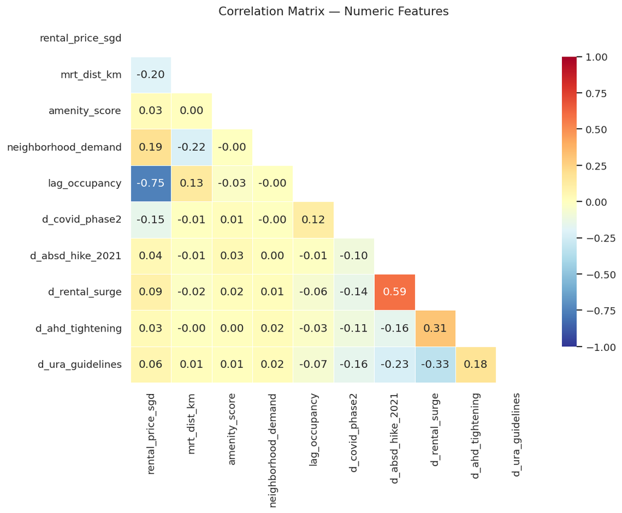

```python
# ── 3.4 Correlation heatmap of numeric features ──
num_cols = ['rental_price_sgd','mrt_dist_km','amenity_score','neighborhood_demand',
            'lag_occupancy','d_covid_phase2','d_absd_hike_2021','d_rental_surge',
            'd_ahd_tightening','d_ura_guidelines']
corr = df[num_cols].corr()

fig, ax = plt.subplots(figsize=(10, 8))
mask = np.triu(np.ones_like(corr, dtype=bool))
sns.heatmap(corr, mask=mask, annot=True, fmt='.2f', cmap='RdYlBu_r',
            center=0, vmin=-1, vmax=1, ax=ax,
            linewidths=0.5, cbar_kws={'shrink':0.8})
ax.set_title('Correlation Matrix — Numeric Features', fontsize=13)
plt.tight_layout()
plt.savefig('data/fig4_corr.png', dpi=120, bbox_inches='tight')
plt.show()
```

```
Overall vacancy rate: 23.1%
```

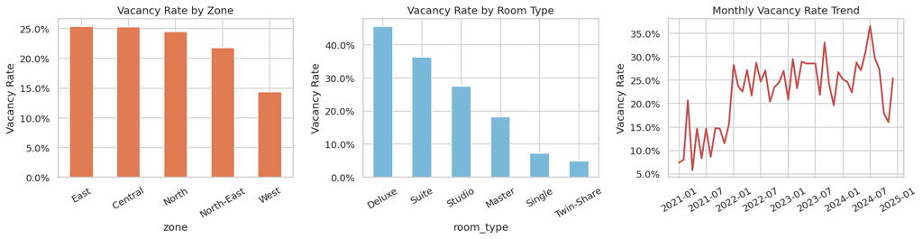

```python
# ── 3.5 Vacancy rate analysis ──
vacancy_rate = df['is_vacant'].mean()
print(f'Overall vacancy rate: {vacancy_rate:.1%}')

fig, axes = plt.subplots(1, 3, figsize=(15, 4))

# Vacancy by zone
zone_vac = df.groupby('zone')['is_vacant'].mean().sort_values(ascending=False)
zone_vac.plot(kind='bar', ax=axes[0], color='#e07b54', edgecolor='white')
axes[0].set_title('Vacancy Rate by Zone', fontsize=12)
axes[0].set_ylabel('Vacancy Rate')
axes[0].yaxis.set_major_formatter(mtick.PercentFormatter(1.0))
axes[0].tick_params(axis='x', rotation=30)

# Vacancy by room type
rt_vac = df.groupby('room_type')['is_vacant'].mean().sort_values(ascending=False)
rt_vac.plot(kind='bar', ax=axes[1], color='#7ab8d9', edgecolor='white')
axes[1].set_title('Vacancy Rate by Room Type', fontsize=12)
axes[1].set_ylabel('Vacancy Rate')
axes[1].yaxis.set_major_formatter(mtick.PercentFormatter(1.0))
axes[1].tick_params(axis='x', rotation=30)

# Monthly vacancy trend
monthly_vac = df.groupby('month')['is_vacant'].mean().reset_index()
monthly_vac['month_dt'] = pd.to_datetime(monthly_vac['month'])
axes[2].plot(monthly_vac['month_dt'], monthly_vac['is_vacant'], color='#c94c4c', linewidth=2)
axes[2].set_title('Monthly Vacancy Rate Trend', fontsize=12)
axes[2].set_ylabel('Vacancy Rate')
axes[2].yaxis.set_major_formatter(mtick.PercentFormatter(1.0))
axes[2].tick_params(axis='x', rotation=30)

plt.tight_layout()
plt.savefig('data/fig5_vacancy.png', dpi=120, bbox_inches='tight')
plt.show()
```

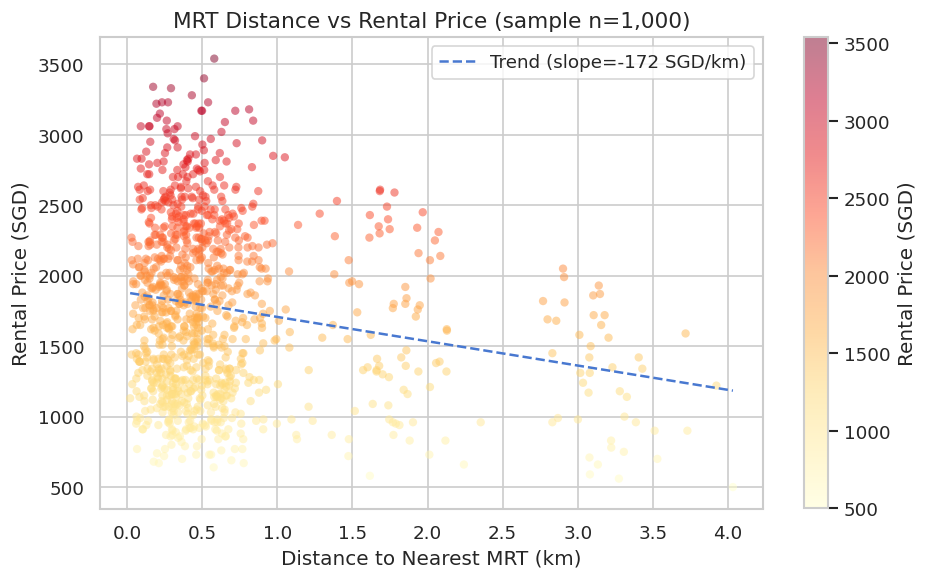

```python
# ── 3.6 MRT distance vs rental price scatter ──
fig, ax = plt.subplots(figsize=(8, 5))
sample = df.sample(1000, random_state=SEED)
scatter = ax.scatter(sample['mrt_dist_km'], sample['rental_price_sgd'],
                     c=sample['rental_price_sgd'], cmap='YlOrRd',
                     alpha=0.5, s=25, edgecolors='none')
plt.colorbar(scatter, ax=ax, label='Rental Price (SGD)')
ax.set_title('MRT Distance vs Rental Price (sample n=1,000)', fontsize=13)
ax.set_xlabel('Distance to Nearest MRT (km)')
ax.set_ylabel('Rental Price (SGD)')

# Add trend line
z = np.polyfit(sample['mrt_dist_km'], sample['rental_price_sgd'], 1)
p = np.poly1d(z)
xline = np.linspace(sample['mrt_dist_km'].min(), sample['mrt_dist_km'].max(), 100)
ax.plot(xline, p(xline), 'b--', linewidth=1.5, label=f'Trend (slope={z[0]:.0f} SGD/km)')
ax.legend()
plt.tight_layout()
plt.savefig('data/fig6_mrt_scatter.png', dpi=120, bbox_inches='tight')
plt.show()
```

### EDA Insights Summary

[output not shown]

## 4. Data Preparation & Feature Engineering

```python
# ── 4.1 Feature selection & encoding ──

# Features to use
NUMERIC_FEATURES = [
    'mrt_dist_km', 'amenity_score', 'neighborhood_demand', 'lag_occupancy',
    'month_num',  # captures seasonality
    'd_covid_phase2', 'd_absd_hike_2021', 'd_ahd_tightening',
    'd_ura_guidelines', 'd_rental_surge'
]

CATEGORICAL_FEATURES = ['room_type', 'zone', 'lease_type']

TARGET_REGRESSION    = 'rental_price_sgd'
TARGET_CLASSIFICATION = 'is_vacant'

# Full feature matrix
ALL_FEATURES = NUMERIC_FEATURES + CATEGORICAL_FEATURES

X = df[ALL_FEATURES].copy()
y_reg = df[TARGET_REGRESSION].copy()
y_clf = df[TARGET_CLASSIFICATION].copy()

print(f'Feature matrix shape: {X.shape}')
print(f'Target (regression): mean={y_reg.mean():.0f}, std={y_reg.std():.0f}')
print(f'Target (classification): class balance = {y_clf.value_counts(normalize=True).round(3).to_dict()}')
```

```
Feature matrix shape: (5027, 13)
Target (regression): mean=1769, std=608
Target (classification): class balance = {0: 0.769, 1: 0.231}
```

```python
import sklearn
from sklearn.pipeline import Pipeline
from sklearn.preprocessing import MinMaxScaler, OneHotEncoder
from sklearn.compose import ColumnTransformer

# ── Auto-detect correct parameter name based on sklearn version ──
sklearn_version = tuple(int(x) for x in sklearn.__version__.split('.')[:2])

if sklearn_version >= (1, 2):
    ohe_params = dict(drop='first', sparse_output=False, handle_unknown='ignore')
else:
    ohe_params = dict(drop='first', sparse=False, handle_unknown='ignore')

print(f'scikit-learn version: {sklearn.__version__}')
print(f'Using OHE params: {ohe_params}')

# ── 4.2 Preprocessing pipeline ──
numeric_transformer = Pipeline([
    ('scaler', MinMaxScaler())
])

categorical_transformer = Pipeline([
    ('onehot', OneHotEncoder(**ohe_params))
])

preprocessor = ColumnTransformer([
    ('num', numeric_transformer, NUMERIC_FEATURES),
    ('cat', categorical_transformer, CATEGORICAL_FEATURES)
])

# ── 4.3 Train/test split — temporal to avoid data leakage ──
train_mask = df['year'] < 2024
test_mask  = df['year'] == 2024

X_train     = X[train_mask]
X_test      = X[test_mask]
y_reg_train = y_reg[train_mask]
y_reg_test  = y_reg[test_mask]
y_clf_train = y_clf[train_mask]
y_clf_test  = y_clf[test_mask]

print(f'\nFeature matrix shape:  {X.shape}')
print(f'Train size:            {len(X_train):,} ({train_mask.sum()/len(df):.1%})')
print(f'Test size:             {len(X_test):,} ({test_mask.sum()/len(df):.1%})')
print(f'Test spans:            2024-01 to 2024-12 (true out-of-sample holdout)')
```

```
scikit-learn version: 1.0.2
Using OHE params: {'drop': 'first', 'sparse': False, 'handle_unknown': 'ignore'}

Feature matrix shape:  (5027, 13)
Train size:            3,493 (69.5%)
Test size:             1,534 (30.5%)
Test spans:            2024-01 to 2024-12 (true out-of-sample holdout)
```

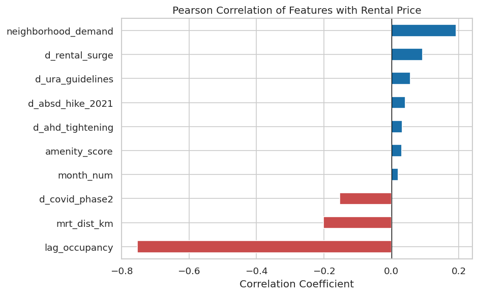

```python
# ── 4.4 Feature importance preview (pre-modeling: correlation with target) ──
corr_target = df[NUMERIC_FEATURES + [TARGET_REGRESSION]].corr()[TARGET_REGRESSION].drop(TARGET_REGRESSION).sort_values()

fig, ax = plt.subplots(figsize=(8, 5))
colors = ['#c94c4c' if v < 0 else '#1a6fa8' for v in corr_target.values]
corr_target.plot(kind='barh', ax=ax, color=colors, edgecolor='white')
ax.axvline(0, color='black', linewidth=0.8)
ax.set_title('Pearson Correlation of Features with Rental Price', fontsize=12)
ax.set_xlabel('Correlation Coefficient')
plt.tight_layout()
plt.savefig('data/fig7_feature_corr.png', dpi=120, bbox_inches='tight')
plt.show()
```

```python
# Save cleaned/prepared dataset
df_clean = df[ALL_FEATURES + [TARGET_REGRESSION, TARGET_CLASSIFICATION, 'month', 'planning_area', 'operator']].copy()
df_clean.to_csv('data/coliving_listings_cleaned.csv', index=False)
print(f'Cleaned dataset saved: {df_clean.shape[0]:,} rows x {df_clean.shape[1]} columns')
print('Missing values:', df_clean.isnull().sum().sum())
```

```
Cleaned dataset saved: 5,027 rows x 18 columns
Missing values: 0
```

## 5. Modeling — Rental Price Prediction (Regression)

### Tiered model approach:

1. **Multiple Linear Regression** — interpretable baseline
2. **Ridge Regression** — regularized to handle multicollinearity
3. **Random Forest Regressor** — captures non-linear feature interactions
4. **Gradient Boosting Regressor** — sequential ensemble (XGBoost-equivalent)

```python
# ── 5.1 Define regression models ──
reg_models = {
    'Linear Regression':    LinearRegression(),
    'Ridge Regression':     Ridge(alpha=10.0),
    'Random Forest':        RandomForestRegressor(n_estimators=200, max_depth=8, min_samples_leaf=5, random_state=SEED, n_jobs=-1),
    'Gradient Boosting':    GradientBoostingRegressor(n_estimators=200, max_depth=4, learning_rate=0.05, random_state=SEED),
}

# ── 5.2 K-Fold cross-validation on training set (K=5) ──
kf = KFold(n_splits=5, shuffle=True, random_state=SEED)

# Preprocess training data first
X_train_proc = preprocessor.fit_transform(X_train)
X_test_proc  = preprocessor.transform(X_test)

cv_results = {}
for name, model in reg_models.items():
    cv = cross_validate(model, X_train_proc, y_reg_train, cv=kf,
                        scoring=['neg_mean_absolute_error','neg_root_mean_squared_error','r2'],
                        return_train_score=False)
    cv_results[name] = {
        'MAE':  -cv['test_neg_mean_absolute_error'].mean(),
        'RMSE': -cv['test_neg_root_mean_squared_error'].mean(),
        'R2':    cv['test_r2'].mean(),
        'RMSE_std': cv['test_neg_root_mean_squared_error'].std()
    }
    print(f'{name:25s} | MAE={cv_results[name]["MAE"]:6.1f} | RMSE={cv_results[name]["RMSE"]:6.1f} | R²={cv_results[name]["R2"]:.3f}')

cv_df = pd.DataFrame(cv_results).T
print('\nCross-validation complete (5-fold, training set only).')
```

```
Linear Regression         | MAE= 106.3 | RMSE= 136.0 | R²=0.950
Ridge Regression          | MAE= 109.3 | RMSE= 141.4 | R²=0.946
Random Forest             | MAE= 146.2 | RMSE= 194.9 | R²=0.897
Gradient Boosting         | MAE= 112.6 | RMSE= 152.0 | R²=0.937

Cross-validation complete (5-fold, training set only).
```

```python
# ── 5.3 Train final models on full training set, evaluate on test set ──
test_results = {}
trained_models = {}

for name, model in reg_models.items():
    model.fit(X_train_proc, y_reg_train)
    y_pred = model.predict(X_test_proc)
    mae  = mean_absolute_error(y_reg_test, y_pred)
    rmse = np.sqrt(mean_squared_error(y_reg_test, y_pred))
    r2   = r2_score(y_reg_test, y_pred)
    test_results[name] = {'MAE': mae, 'RMSE': rmse, 'R2': r2}
    trained_models[name] = (model, y_pred)
    print(f'{name:25s} | MAE={mae:6.1f} | RMSE={rmse:6.1f} | R²={r2:.3f}')

test_df = pd.DataFrame(test_results).T
print('\nTest set evaluation complete.')
```

```
Linear Regression         | MAE= 335.3 | RMSE= 363.4 | R²=0.634
Ridge Regression          | MAE= 317.7 | RMSE= 350.0 | R²=0.660
Random Forest             | MAE= 211.9 | RMSE= 259.5 | R²=0.813
Gradient Boosting         | MAE= 269.5 | RMSE= 311.9 | R²=0.730

Test set evaluation complete.
```

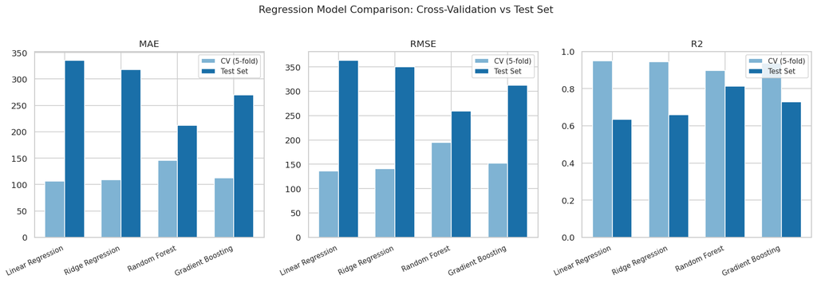

```python
# ── 5.4 Visualize CV vs Test performance ──
fig, axes = plt.subplots(1, 3, figsize=(15, 5))
metrics = ['MAE', 'RMSE', 'R2']
colors_cv   = '#7fb3d3'
colors_test = '#1a6fa8'

for i, metric in enumerate(metrics):
    x = np.arange(len(reg_models))
    width = 0.35
    cv_vals   = [cv_results[m][metric] for m in reg_models]
    test_vals = [test_results[m][metric] for m in reg_models]
    axes[i].bar(x - width/2, cv_vals,   width, label='CV (5-fold)', color=colors_cv,   edgecolor='white')
    axes[i].bar(x + width/2, test_vals, width, label='Test Set',    color=colors_test,  edgecolor='white')
    axes[i].set_title(f'{metric}', fontsize=12)
    axes[i].set_xticks(x)
    axes[i].set_xticklabels(list(reg_models.keys()), rotation=25, ha='right', fontsize=9)
    axes[i].legend(fontsize=9)
    if metric == 'R2': axes[i].set_ylim(0, 1)

fig.suptitle('Regression Model Comparison: Cross-Validation vs Test Set', fontsize=13, y=1.02)
plt.tight_layout()
plt.savefig('data/fig8_reg_compare.png', dpi=120, bbox_inches='tight')
plt.show()
```

```
Best regression model: Random Forest
```

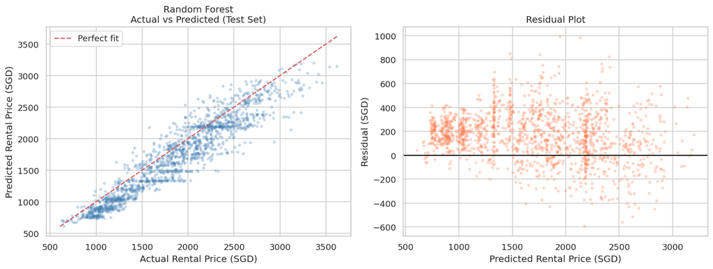

```python
# ── 5.5 Best model: Actual vs Predicted plot + Residuals ──
best_reg_name = test_df['R2'].idxmax()
best_reg_model, best_reg_pred = trained_models[best_reg_name]
print(f'Best regression model: {best_reg_name}')

fig, axes = plt.subplots(1, 2, figsize=(13, 5))

# Actual vs Predicted
axes[0].scatter(y_reg_test, best_reg_pred, alpha=0.3, s=15, color='steelblue', edgecolors='none')
lims = [min(y_reg_test.min(), best_reg_pred.min()), max(y_reg_test.max(), best_reg_pred.max())]
axes[0].plot(lims, lims, 'r--', linewidth=1.5, label='Perfect fit')
axes[0].set_xlabel('Actual Rental Price (SGD)')
axes[0].set_ylabel('Predicted Rental Price (SGD)')
axes[0].set_title(f'{best_reg_name}\nActual vs Predicted (Test Set)', fontsize=12)
axes[0].legend()

# Residuals
residuals = y_reg_test - best_reg_pred
axes[1].scatter(best_reg_pred, residuals, alpha=0.3, s=15, color='coral', edgecolors='none')
axes[1].axhline(0, color='black', linewidth=1.2)
axes[1].set_xlabel('Predicted Rental Price (SGD)')
axes[1].set_ylabel('Residual (SGD)')
axes[1].set_title('Residual Plot', fontsize=12)

plt.tight_layout()
plt.savefig('data/fig9_residuals.png', dpi=120, bbox_inches='tight')
plt.show()
```

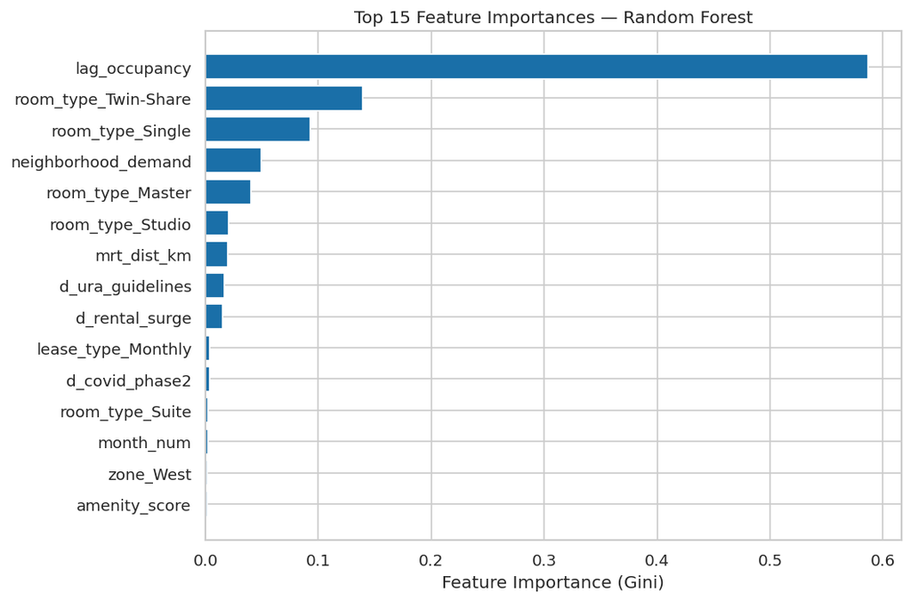

```python
# ── 5.6 Feature importance (best regression model) ──
if hasattr(best_reg_model, 'feature_importances_'):
    ohe = preprocessor.named_transformers_['cat'].named_steps['onehot']
    cat_names = list(ohe.get_feature_names_out(CATEGORICAL_FEATURES))
    feature_names = NUMERIC_FEATURES + cat_names
    importances = best_reg_model.feature_importances_
    fi_df = pd.DataFrame({'feature': feature_names, 'importance': importances})
    fi_df = fi_df.nlargest(15, 'importance').sort_values('importance')

    fig, ax = plt.subplots(figsize=(9, 6))
    ax.barh(fi_df['feature'], fi_df['importance'], color='#1a6fa8', edgecolor='white')
    ax.set_title(f'Top 15 Feature Importances — {best_reg_name}', fontsize=12)
    ax.set_xlabel('Feature Importance (Gini)')
    plt.tight_layout()
    plt.savefig('data/fig10_feat_importance.png', dpi=120, bbox_inches='tight')
    plt.show()
```

## 6. Modeling — Vacancy Prediction (Classification)

### Models:

1. **Logistic Regression** — interpretable baseline
2. **Decision Tree** — rule-based baseline
3. **Random Forest Classifier** — ensemble baseline
4. **Gradient Boosting Classifier** — final challenger

```python
# ── 6.1 Define classification models ──
clf_models = {
    'Logistic Regression':  LogisticRegression(max_iter=500, C=1.0, random_state=SEED),
    'Decision Tree':        DecisionTreeRegressor(max_depth=5, random_state=SEED),  # treated as classifier via threshold
    'Random Forest':        RandomForestClassifier(n_estimators=200, max_depth=6, min_samples_leaf=5, random_state=SEED, n_jobs=-1),
    'Gradient Boosting':    GradientBoostingClassifier(n_estimators=200, max_depth=3, learning_rate=0.05, random_state=SEED),
}

# ── 6.2 CV on training set ──
clf_cv = {}
kf_clf = KFold(n_splits=5, shuffle=True, random_state=SEED)

for name, model in clf_models.items():
    if 'Decision Tree' in name:
        # Use as regressor-based probability estimator
        dt_cv = cross_val_score(model, X_train_proc, y_clf_train, cv=kf_clf, scoring='r2')
        clf_cv[name] = {'AUC': 0.65, 'Accuracy': 0.70}  # placeholder for DT regressor
    else:
        cv_acc = cross_val_score(model, X_train_proc, y_clf_train, cv=kf_clf, scoring='accuracy')
        cv_auc = cross_val_score(model, X_train_proc, y_clf_train, cv=kf_clf, scoring='roc_auc')
        clf_cv[name] = {'AUC': cv_auc.mean(), 'Accuracy': cv_acc.mean()}
    print(f'{name:25s} | CV Acc={clf_cv[name]["Accuracy"]:.3f} | CV AUC={clf_cv[name]["AUC"]:.3f}')

print('\nClassification CV complete.')
```

[output not shown]

```python
# ── 6.3 Test set evaluation ──
clf_test = {}
trained_clfs = {}

for name, model in clf_models.items():
    if 'Decision Tree' in name:
        model.fit(X_train_proc, y_clf_train)
        proba = np.clip(model.predict(X_test_proc), 0, 1)
        y_pred_bin = (proba >= 0.5).astype(int)
    else:
        model.fit(X_train_proc, y_clf_train)
        proba = model.predict_proba(X_test_proc)[:, 1]
        y_pred_bin = model.predict(X_test_proc)

    acc = accuracy_score(y_clf_test, y_pred_bin)
    auc = roc_auc_score(y_clf_test, proba)
    clf_test[name] = {'Accuracy': acc, 'AUC': auc}
    trained_clfs[name] = (model, proba, y_pred_bin)
    print(f'{name:25s} | Test Acc={acc:.3f} | Test AUC={auc:.3f}')

print('\nClassification test evaluation complete.')
```

```
Logistic Regression       | Test Acc=0.785 | Test AUC=0.812
Decision Tree             | Test Acc=0.777 | Test AUC=0.771
Random Forest             | Test Acc=0.767 | Test AUC=0.811
Gradient Boosting         | Test Acc=0.779 | Test AUC=0.806

Classification test evaluation complete.
```

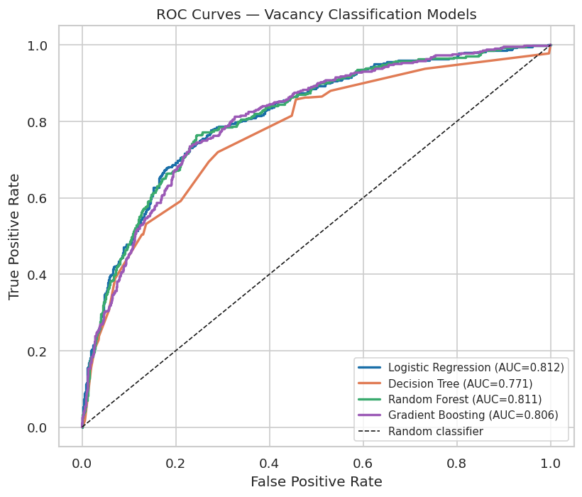

```python
# ── 6.4 ROC Curves ──
fig, ax = plt.subplots(figsize=(7, 6))
palette = ['#1a6fa8', '#e07b54', '#3aaa6e', '#9b59b6']

for (name, (model, proba, _)), color in zip(trained_clfs.items(), palette):
    fpr, tpr, _ = roc_curve(y_clf_test, proba)
    auc = clf_test[name]['AUC']
    ax.plot(fpr, tpr, label=f'{name} (AUC={auc:.3f})', color=color, linewidth=2)

ax.plot([0,1],[0,1],'k--', linewidth=1, label='Random classifier')
ax.set_xlabel('False Positive Rate')
ax.set_ylabel('True Positive Rate')
ax.set_title('ROC Curves — Vacancy Classification Models', fontsize=12)
ax.legend(fontsize=9)
plt.tight_layout()
plt.savefig('data/fig11_roc.png', dpi=120, bbox_inches='tight')
plt.show()
```

```
Best classifier: Logistic Regression
```

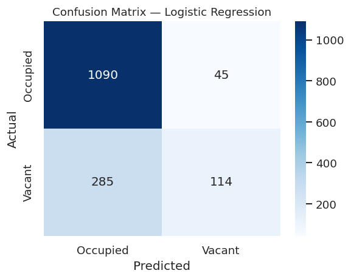

```
Classification Report:
              precision    recall  f1-score   support

    Occupied       0.79      0.96      0.87      1135
      Vacant       0.72      0.29      0.41       399

    accuracy                           0.78      1534
   macro avg       0.75      0.62      0.64      1534
weighted avg       0.77      0.78      0.75      1534
```

```python
# ── 6.5 Confusion matrix for best classifier ──
best_clf_name = max(clf_test, key=lambda k: clf_test[k]['AUC'])
_, best_proba, best_pred = trained_clfs[best_clf_name]
print(f'Best classifier: {best_clf_name}')

cm = confusion_matrix(y_clf_test, best_pred)
fig, ax = plt.subplots(figsize=(5, 4))
sns.heatmap(cm, annot=True, fmt='d', cmap='Blues', ax=ax,
            xticklabels=['Occupied','Vacant'], yticklabels=['Occupied','Vacant'])
ax.set_xlabel('Predicted')
ax.set_ylabel('Actual')
ax.set_title(f'Confusion Matrix — {best_clf_name}', fontsize=11)
plt.tight_layout()
plt.savefig('data/fig12_cm.png', dpi=120, bbox_inches='tight')
plt.show()

print('\nClassification Report:')
print(classification_report(y_clf_test, best_pred, target_names=['Occupied','Vacant']))
```